# Matplotlib Basics

Matplotlib is a comprehensive library for creating static, animated, and interactive visualizations in Python. It has very similar plotting capabilties like MATLAB's.

- Offical page: https://matplotlib.org/
- Quick start guide: https://matplotlib.org/stable/users/explain/quick_start.html#quick-start
- Tutorial: https://matplotlib.org/stable/tutorials/pyplot.html#sphx-glr-tutorials-pyplot-py
- Sample figures creation: https://matplotlib.org/stable/plot_types/index.html

### Anatomy of a matlab figure

[figure not shown]

## Coding styles:

You can use matplotlib in 2 ways:

- Implicit interface: Rely on pyplot to implicitly create and manage the Figures and Axes, and use pyplot functions for plotting.
- Explicit interface: Explicitly create Figures and Axes, and call methods on them (the "object-oriented (OO) style").

## Installation

conda install matplotlib  
or  
pip install matplotlib

### Importing and setting for visualization in notebook

adding **plt.show()** at the end will display the open figures

```python
import numpy as np
import matplotlib.pyplot as plt
# for notebook visualization
%matplotlib inline
```

*matplotlib.pyplot* is a collection of functions that make matplotlib work like *MATLAB*.

### Input data usually numpy.array and pandas.DataFrame

#### Example numpy array

```python
#set x and y
x= np.linspace(0,5,11)
y = x**2
x
```

```
array([0. , 0.5, 1. , 1.5, 2. , 2.5, 3. , 3.5, 4. , 4.5, 5. ])
```

```python
y
```

```
array([ 0.  ,  0.25,  1.  ,  2.25,  4.  ,  6.25,  9.  , 12.25, 16.  ,
       20.25, 25.  ])
```

### Single plot

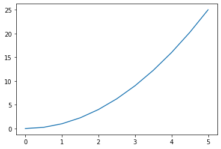

```python
#A simple plot
#plt.figure(figsize=(4,3))
plt.plot(x,y) # generate a line plot
plt.show()
```

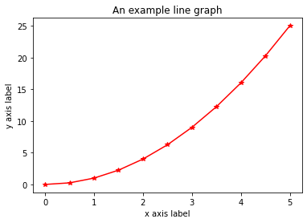

```python
#Single plot with line style option
plt.plot(x,y,'r-*')
plt.xlabel('x axis label')
plt.ylabel('y axis label')
plt.title('An example line graph')

plt.show() # display all open figures
```

### Multiple plots

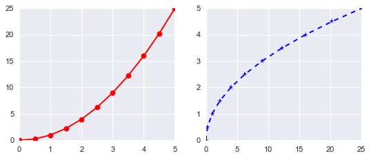

```python
#Mutiple subplot(nrows,ncols,plot_index)
plt.figure(figsize=(8,3))
plt.subplot(1,2,1) # 1 row 2 cols
plt.plot(x,y,'r-o')
plt.subplot(1,2,2)
plt.plot(y,x,'b--*')
plt.show()
```

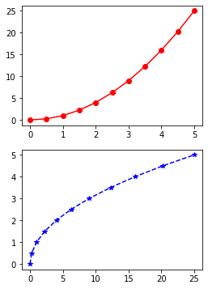

```python
#Changing figure size
#Mutiple subplot(nrows,ncols,plot_no)
plt.figure(figsize=(4,6))
plt.subplot(2,1,1)
plt.plot(x,y,'r-o') # 2 rows, 1 col

plt.subplot(2,1,2)
plt.plot(y,x,'b--*')
plt.show()
```

## Object Oriented method

- More flexible and control
- Instantitiate fig object
- Invoke differnt methods as needed

**Figure:** figure keeps track of all the child Axes  
**Axes:** An axes is an Artist attached to a Figure that contains a region for plotting data  
**Axis:** objects that set the scale and limits and generate ticks (the marks on the Axis) and ticklabels (strings labeling the ticks)  
**Artist:** everything visible on the Figure is an Artist

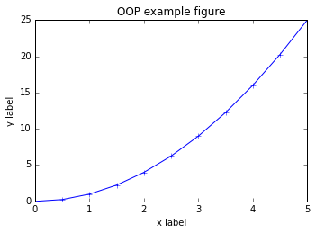

```python
#Create an empty canvas
fig = plt.figure()

axes = fig.add_axes([0.1,0.1,0.7,0.7]) #left, bottom, width, height
axes.plot(x,y,'b+-')
axes.set_xlabel('x label')
axes.set_ylabel('y label')
axes.set_title('OOP example figure')
```

## Multiple axes

Main figure and inset figure

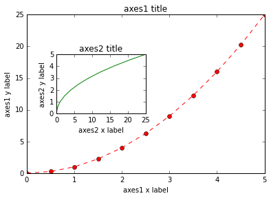

```python
#Create an empty canvas
fig = plt.figure() # an empty figure with no Axes

# add axes

axes1 = fig.add_axes([0.1,0.1,0.8,0.8])
axes2 = fig.add_axes([0.2,0.4,0.3,0.3])

#Plot with axes1
#axes1.plot(x,y,'r--')
axes1.plot(x,y,'ro--')
axes1.set_xlabel('axes1 x label')
axes1.set_ylabel('axes1 y label')
axes1.set_title('axes1 title')

#Plot with axes2
axes2.plot(y,x,'g-')
axes2.set_xlabel('axes2 x label')
axes2.set_ylabel('axes2 y label')
axes2.set_title('axes2 title')
plt.show()
```

## Suplots

plt.subplots() for automatic axes manager

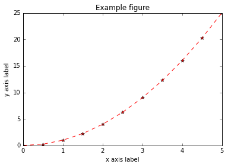

```python
fig, axes = plt.subplots() # A figure with a single axes
axes.plot(x,y,'r*--')
axes.set_xlabel('x axis label')
axes.set_ylabel('y axis label')
axes.set_title('Example figure')
plt.show()
```

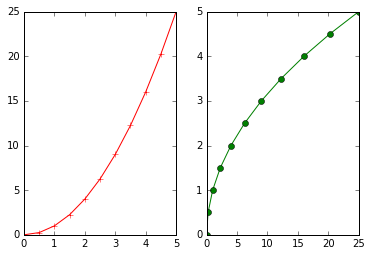

```python
# Creating 2 axes
fig, axes = plt.subplots(nrows=1,ncols=2) # A figure with 1x2 grid axes
# accessing through indexing
axes[0].plot(x,y,'r+-')
axes[1].plot(y,x,'go-')

# display the figure
#fig
plt.show()
```

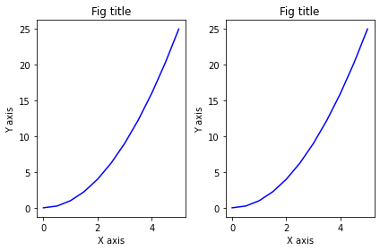

```python
# accessing through loop
# Creating 2 axes
fig, axes = plt.subplots(nrows=1,ncols=2)
for ax in axes:
    ax.plot(x,y,'b-')
    ax.set_xlabel('X axis')
    ax.set_ylabel('Y axis')
    ax.set_title('Fig title')
plt.tight_layout() # for non-overlapping figure
#fig
```

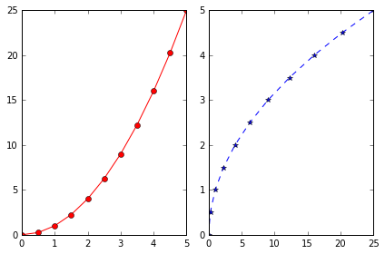

```python
# using tuple unpacking for multple axes
fig, (axes1,axes2) = plt.subplots(1,2)


axes1.plot(x,y,'ro-')
axes2.plot(y,x,'b*--')

#for non-overlaping figure
plt.tight_layout()
```

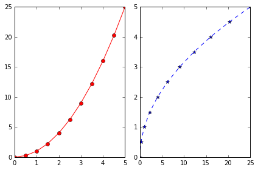

```python
#display the figure again
fig
```

## Fig size and DPI

Figure size can be changed using:

- figsize: Width, height in inches.
- dpi:The resolution of the figure in dots-per-inch.

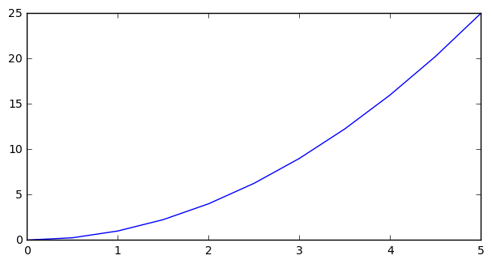

```python
fig = plt.figure(figsize=(8,4),dpi=100) # an empty figure with no Axes
axes = fig.add_axes([0,0,0.7,0.7])
axes.plot(x,y)
plt.show()
```

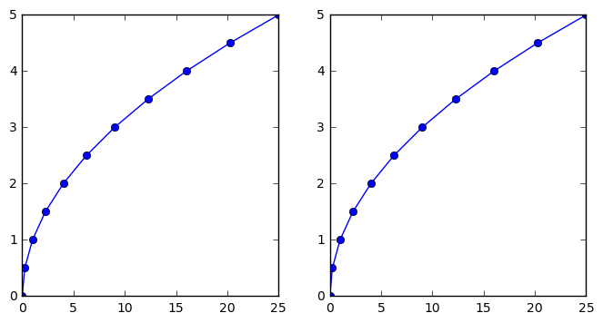

```python
#Multiple figures with subplot
fig,axes = plt.subplots(1,2,figsize=(8,4),dpi=100)
for ax in axes:
    ax.plot(y,x,'bo-')
```

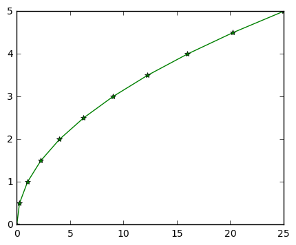

```python
#Single figure with subplot
fig, axes = plt.subplots(figsize=(5,4),dpi=100)
axes.plot(y,x,'g-*')
plt.show()
```

### Saving a figure

fig.savefig() method

```python
fig.savefig('LinePlot.jpg',dpi=200)
```

## Legends

you can add legend using label="label text" and calling legend() method

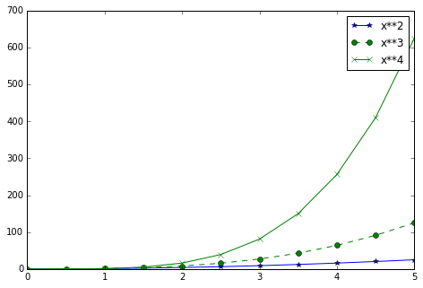

```python
fig = plt.figure()
ax = fig.add_axes([0,0,1,1])

ax.plot(x,x**2,'b-*',label='x**2')
ax.plot(x,x**3,'g--o',label='x**3')
ax.plot(x,x**4,'g-x',label='x**4')
#ax.legend(loc=1) # top right corner
#ax.legend(loc=2) # top left corner
#ax.legend(loc=3) #lower left corner
#ax.legend(loc=4) #lower right corner
ax.legend(loc=1)
#ax.legend(loc=0) #let matplotlib decides to place legend
plt.show()
```

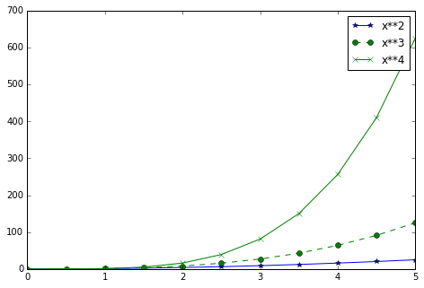

```python
#draw the fig again
fig
```

## Line and marker styles

We can change a number of styling parameters in graph plotting

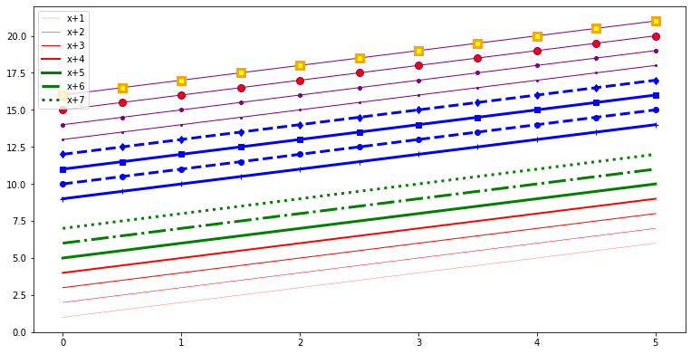

```python
fig = plt.figure(figsize=(10,5))
ax = fig.add_axes([0,0,1,1])

#Changing different linewidth
ax.plot(x, x+1, color="red", linewidth=0.25, label='x+1')
ax.plot(x, x+2, color="red", linewidth=0.50, label='x+2')
ax.plot(x, x+3, color="red", linewidth=1.00, label='x+3')
ax.plot(x, x+4, color="red", linewidth=2.00, label='x+4')

# Changing different line style:  options are: '-', '--', '-.', ':'
ax.plot(x, x+5, color="green", lw=3, linestyle='-',label='x+5')
ax.plot(x, x+6, color="green", lw=3, ls='-.',label='x+6')
ax.plot(x, x+7, color="green", lw=3, ls=':',label='x+7')

# Changing different markers. options are = '+', 'o', '*', 's (squre)', 'd (diamond)', '.', '1', '2', '3', '4', ...
ax.plot(x, x+ 9, color="blue", lw=3, ls='-', marker='+')
ax.plot(x, x+10, color="blue", lw=3, ls='--', marker='o')
ax.plot(x, x+11, color="blue", lw=3, ls='-', marker='s')
ax.plot(x, x+12, color="blue", lw=3, ls='--', marker='d')

# Changing marker size and style
ax.plot(x, x+13, color="purple", lw=1, ls='-', marker='o', markersize=2)
ax.plot(x, x+14, color="purple", lw=1, ls='-', marker='o', markersize=4)
ax.plot(x, x+15, color="purple", lw=1, ls='-', marker='o', markersize=8, markerfacecolor="red")
ax.plot(x, x+16, color="purple", lw=1, ls='-', marker='s', markersize=8,
        markerfacecolor="yellow", markeredgewidth=3, markeredgecolor="orange");
ax.legend()
plt.show()
```

## Customizing Plot range

- axis('tight): tightly fitted axis
- custom axis: set_xlim() and set_ylim()

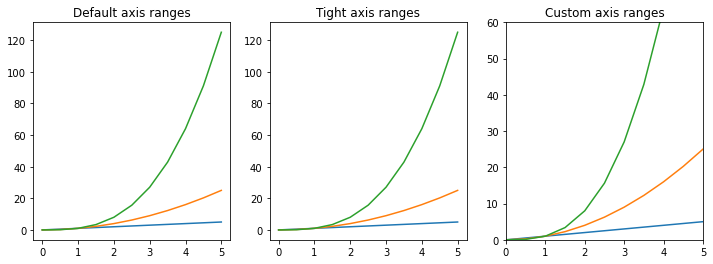

```python
fig, ax = plt.subplots(1,3, figsize=(12,4))

#Deafult plot range
ax[0].plot(x,x,x,x**2,x,x**3)
ax[0].set_title('Default axis ranges')

#tight plot range
ax[1].plot(x,x,x,x**2,x,x**3)
ax[1].axis('tight')
ax[1].set_title('Tight axis ranges')

#Custom plot range
ax[2].plot(x,x,x,x**2,x,x**3)
ax[2].set_xlim([0,5])
ax[2].set_ylim([0,60])
ax[2].set_title('Custom axis ranges')
```

# Some other plot types

- scatter plot
- histogram
- box plot

## Scatter plot

A scatter plot of *y* vs. *x* with varying marker size and/or color.

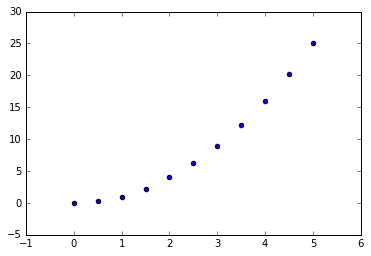

```python
plt.scatter(x,y)
plt.show()
```

## Histogram

Compute and draw the histogram of *x*

### To see the available style sheet references

```python
import matplotlib
matplotlib.style.available
```

```
['Solarize_Light2',
 '_classic_test_patch',
 'bmh',
 'classic',
 'dark_background',
 'fast',
 'fivethirtyeight',
 'ggplot',
 'grayscale',
 'seaborn',
 'seaborn-bright',
 'seaborn-colorblind',
 'seaborn-dark',
 'seaborn-dark-palette',
 'seaborn-darkgrid',
 'seaborn-deep',
 'seaborn-muted',
 'seaborn-notebook',
 'seaborn-paper',
 'seaborn-pastel',
 'seaborn-poster',
 'seaborn-talk',
 'seaborn-ticks',
 'seaborn-white',
 'seaborn-whitegrid',
 'tableau-colorblind10']
```

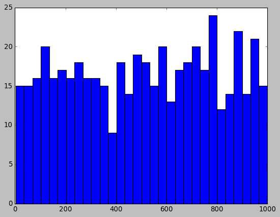

```python
from random import sample

data = sample(range(1,1000),500) # Chooses k unique random elements from a population sequence or set.
plt.style.use('classic')
plt.hist(data,bins=30)
plt.show()
```

## Box-plot

Make a box and whisker plot for each column of *x* or each vector in sequence *x*. The box extends from the lower to upper quartile values of the data, with a line at the median.

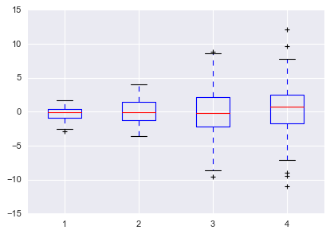

```python
plt.figure(figsize=(6,4))
# generate a nested list with 4 different std values
data = [np.random.normal(0,std,100) for std in range(1,5)]
plt.style.use('seaborn')

plt.boxplot(x=data)

plt.show()
```

**Further reading for interested users:** https://github.com/rougier/matplotlib-tutorial  
**Matplotlib source code:** https://github.com/matplotlib/matplotlib